# **Estudio de datos de Airbnb en la ciudad de París entre semana**

Juan Jose Diaz Parra, Mateo Silva Lasso, Santiago Espinosa, Melissa Dayana Mora

2023-05-14

### **Antecedentes:**

Airbnb es una plataforma de alojamiento en línea que permite a los usuarios alquilar viviendas privadas a corto plazo. En los últimos años, el aumento del turismo ha llevado a un aumento en el número de alojamientos de Airbnb en todo el mundo, llegando a competir incluso con las grandes compañías hoteleras en el mundo. La capital de Francia, París, es la ciudad con mayor número de visitantes en un año y tiene una gran cantidad de alojamientos de Airbnb. Si analizamos el comportamiento de este modelo de negocio en esta ciudad tan importante para el turismo podemos entender de forma más completa las características de este negocio y ser capaces de tomar decisiones conscientes dentro de este negocio.

$$$$

### **Definición del problema**

Como se mencionó anteriormente, la aplicación de Airbnb ha tenido un crecimiento supremamente acelerado y una expansión a pasos agigantados, lo que hace que sea muy difícil estimar las indicadores que permitan conocer el comportamiento de estos alojamientos, y poder tomar decisiones a partir de esta información. Es por esto que este informe se va a encargar en estimar indicadores que nos permitan tener una idea general de lo que son los alojamientos de Airbnb en el mundo o en este caso, específicamente en París, Francia.

$$$$

### **Objetivos del proyecto:**

#### **Objetivo General**

Analizar el comportamiento del modelo de negocio de Airbnb en la ciudad de París durante una semana, considerando variables como la capacidad de las habitaciones, la distancia al centro de la ciudad, el tipo de habitación, la privacidad de la habitación, el nivel de limpieza y la tarifa total, para comprender cómo se utilizan estos alojamientos y poder tomar decisiones informadas sobre la regulación del mercado de alquileres.

#### **Objetivos específicos:**

- **Objetivo 1:** Calcular las estadisticas descriptivas de las variables cuantitativas como puede ser la media, mediana, moda y desviacion estadar.
- **Objetivo 2:** Calcular las estadisticas descriptivas de las variables cualitativas a traves de tablas de frecuencias y graficas.
- **Objetivo 3:** Ilustrar de forma grafica el comportamiento de las variables como puede ser por medio de graficas de cajas y bigotes, graficos de barras, histogramas, etc…
- **Objetivo 4:** Plantear intervalos de confianza para cada una de las variables respecto a la media o la proporcion dependiendo del tipo de variable.
- **Objetivo 5:** Plantear hipótesis de la media o la proporcion para cada una de las variables, dependiendo si esta es cualitativa o cuantitativa.
- **Objetivo 6:** Realizar graficas que ilustren la posible relacion entre 2 variables del estudio, como pueden ser graficos de barras apliadas para las variables cualitativas.
- **Objetivo 7:** Realizar hipotesis para a la diferencia de medias en muestras independientes y /o dependientes.
- **Objetivo 8:** Conocer si existen diferencias entre la distrubicion de las medias para variables cuantitativas mediante la prueba de anova.
- **Objetivo 9:** Conocer si existen diferencias en la proporcion para variables cualitativas mediante la prueba de Ji-Cuadrado
- **Objetivo 10:** Plantear una relacion lineal para nuestras variables y ver como se comporta este modelo
- **Objetivo 11:** Validar los supuestos de regresion del modelo de regresion lineal

$$$$

### **Recolección de datos y análisis de resultados:**

$$$$

#### **Definición de la población de estudio:**

La población de estudio se refiere a las publicaciones de alojamientos disponibles los días entre semana durante el año 2015 en la plataforma Airbnb en París. Cómo se están considerando todas las publicaciones de la anteriormente mencionada plataforma, la población podría incluir diferentes tipos de alojamientos, como apartamentos, casas, habitaciones, entre otros.

$$$$

#### **Definición del metodo de muestreo:**

En el contexto anteriormente descrito, sería mejor utilizar el método de muestreo aleatorio simple para seleccionar una muestra de alojamientos de Airbnb a partir del archivo que contiene más de 3000 publicaciones. Con lo anteriormente mencionado se asegura que cada publicación tiene la misma probabilidad de ser seleccionada y, por lo tanto, que la muestra obtenida sea representativa de la población de alojamientos de Airbnb en cuestión.

$$$$

### **Definición de las variables de estudio:**

Dentro de nuestro estudio se van a estudiar ocho variables, de las cuales 4 van a ser cuantitativas y 4 van a ser cualitativas, tal como se muestran a continuacion:

#### **Variables cuantitativas:**

- *Puntaje de limpieza:* Puntaje que determina el nivel de limpieza del alojamiento, se mide en una escala del 1 al 10.
- *Precio final:* Se refiere al precio final por el alojamiento, medido en euros.
- *Capacidad de personas:* Capacidad de personas que permite el alojamiento.
- *Distancia al centro:* Distancia entre del alojamiento al centro de la ciudad de París, medido en Kilometros.

#### **Variables cualitativas:**

- *Tipo de alojamiento:* Tipo de alojamiento que es ofrecido. Los valores que puede tomar son los siguientes: Casa o apartamento entero, cuarto privado, cuarto compartido.
- *Cuarto privado:* Es el valor de si el cuarto es privado o no. Esta variable es de tipo booleano, es decir que solo puede tener los valores de TRUE y FALSE.
- *Multiples cuartos:* Es el valor de si el alojamiento tiene multiples cuartos o no. Esta variable es de tipo booleano, es decir que solo puede tener los valores de TRUE y FALSE.
- *Fines de negocio:* Es el valor de si el alojamiento se puede usar para fines de negocios o no. Esta variable es de tipo booleano, es decir que solo puede tener los valores de TRUE y FALSE.

## **Exploración de datos**

A continuación importamos todas las librerias que se van a usar dentro de este informe:

```r
# Importar todas las librerias necesarias para el analisis
library(e1071)
library(readr)
library(tidyverse)
library(dplyr)
library(xts)
library(psych)
library(gmodels)
library(MASS)
library(fitdistrplus)
library(lmtest)
library(fdth)
library(readxl)
library(ggplot2)
library(plotly)
library(PASWR2)
library(lattice)
library(descr)
library(openxlsx)
library(kableExtra)
library(pastecs)
library(moments)
```

La base de datos de la cual vamos a explorar está dentro de un formato .csv y, para una mayor practicidad, vamos a guardar cada una de las variables a explorar dentro de un elemento distinto de nuestro entorno, tal como se muestra a continuación:

```r
#Variables cuantitativas
CalificacionDeLimpieza <- datos$cleanliness_rating
PrecioFinal <- datos$realSum
CapacidadPersonas <- datos$person_capacity
DistanciaCentro <- datos$dist

#Variables cualitativas
TipoDeCuarto<-  datos$room_type
CuartoPrivado <- datos$room_private
PoseeMasDeUnCuarto <- datos$multi
FinesDeNegocios <- datos$biz
```

## **Estadística descriptiva para las Variables cuantitativas**

### **Calificación de limpieza**

Antes de realizar el analisis de esta variable, vamos a realizar un filtro de valores atipicos, este se vera representado con los siguientes graficos:

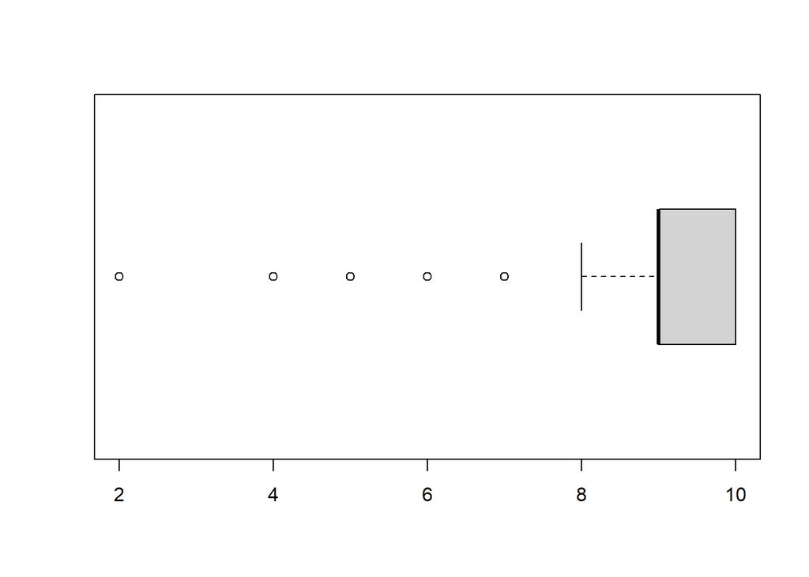

```r
boxplot(CalificacionDeLimpieza, horizontal = TRUE)
```

Si le quitamos los valores atípicos se vería algo así:

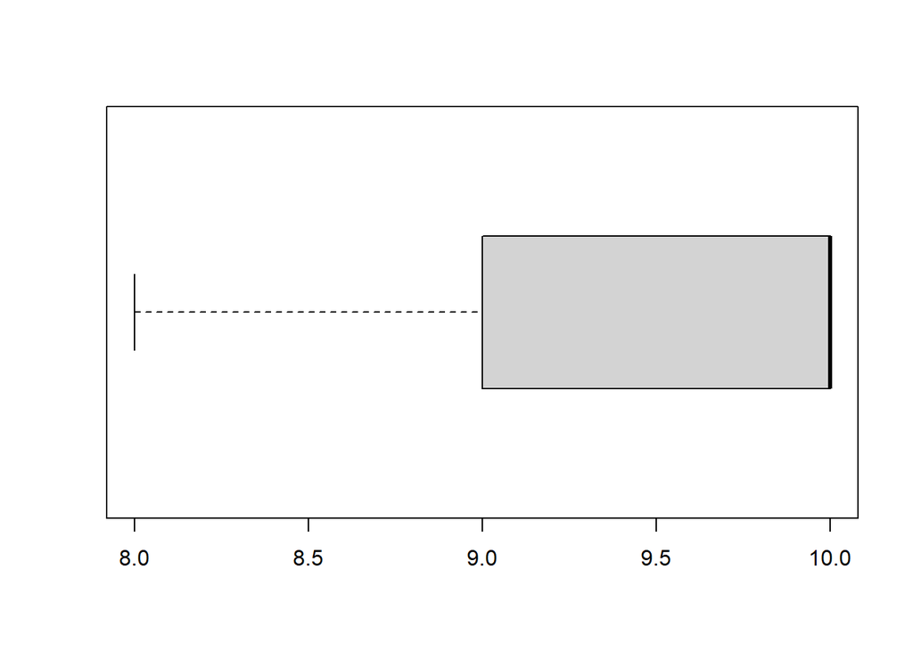

```r
mean_val <- mean(CalificacionDeLimpieza)
sd_val <- sd(CalificacionDeLimpieza)
primerFiltro <- CalificacionDeLimpieza[CalificacionDeLimpieza < (mean_val + 2.9*sd_val) & CalificacionDeLimpieza > (mean_val - 2.9*sd_val)]
mean_val2 <- mean(primerFiltro)
sd_val2 <- sd(primerFiltro)
segundoFiltro <- primerFiltro[primerFiltro < (mean_val2 + 2.9*sd_val2) & primerFiltro > (mean_val2 - 2.9*sd_val2)]
mean_val3 <- mean(segundoFiltro)
sd_val3 <- sd(segundoFiltro)
CalificacionDeLimpiezaSinAtipicos <- segundoFiltro[segundoFiltro < (mean_val3 + 2.9*sd_val3) & segundoFiltro > (mean_val3 - 2.9*sd_val3)]
boxplot(CalificacionDeLimpiezaSinAtipicos, horizontal = TRUE)
```

*Mínimo:*

```
## [1] 8
```

*Máximo:*

```
## [1] 10
```

*Rango:*

```
## [1] 2
```

*Media:*

```
## [1] 9.407258
```

*Desviación estándar:*

```
## [1] 0.6831472
```

Vemos que la desviacion estandar es menor a 20, por lo que podemos decir que la media si es representativa en esta distribucion

*Coeficiente de variación:*

```
## [1] 0.07261917
```

*Cuartiles 1 y 3:*

```
## [1] 9
```

```
## [1] 10
```

*Rango intercuartil:*

```
## [1] 1
```

*Cerco inferior y superior:*

```
## [1] 7.5
```

```
## [1] 11.5
```

*Coeficiente de simetria*

```
## [1] -0.7226814
```

Vemos que el valor de este coeficiente es negativo, podemos decir que esta variable tiene una asimetria hacia la izquierda.

*Curtosis*

```
## [1] 2.369624
```

*Histograma*

```r
calificacion2 <- cut(CalificacionDeLimpiezaSinAtipicos, c(seq(from = 7, to = 11, by = 1),65), include.lowest=TRUE)
tabla.2 <- freq(ordered(calificacion2))
```

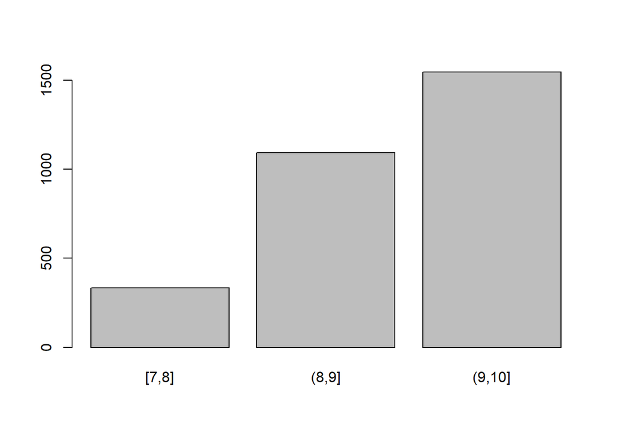

*Tabla de frecuencias*

```r
tabla.2
```

```
## ordered(calificacion2)
##        Frequency Percent Cum Percent
## [7,8]        335   11.26       11.26
## (8,9]       1094   36.76       48.02
## (9,10]      1547   51.98      100.00
## Total       2976  100.00
```

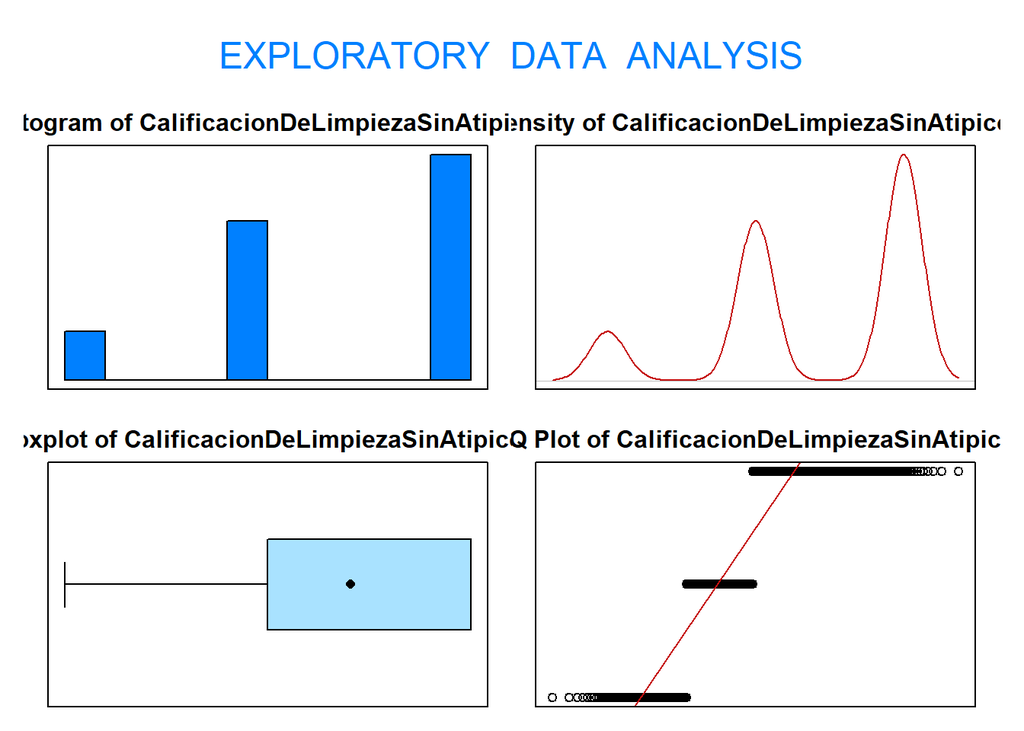

```
## Size (n)  Missing  Minimum   1st Qu     Mean   Median   TrMean   3rd Qu
## 2976.000    0.000    8.000    9.000    9.407   10.000    9.452   10.000
##      Max    Stdev      Var  SE Mean   I.Q.R.    Range Kurtosis Skewness
##   10.000    0.683    0.467    0.013    1.000    2.000   -0.632   -0.722
## SW p-val
##    0.000
```

```r
eda(CalificacionDeLimpiezaSinAtipicos)
```

### **Precio final**

Antes de realizar el analisis de esta variable, vamos a realizar un filtro de valores atipicos, este se vera representado con los siguientes graficos:

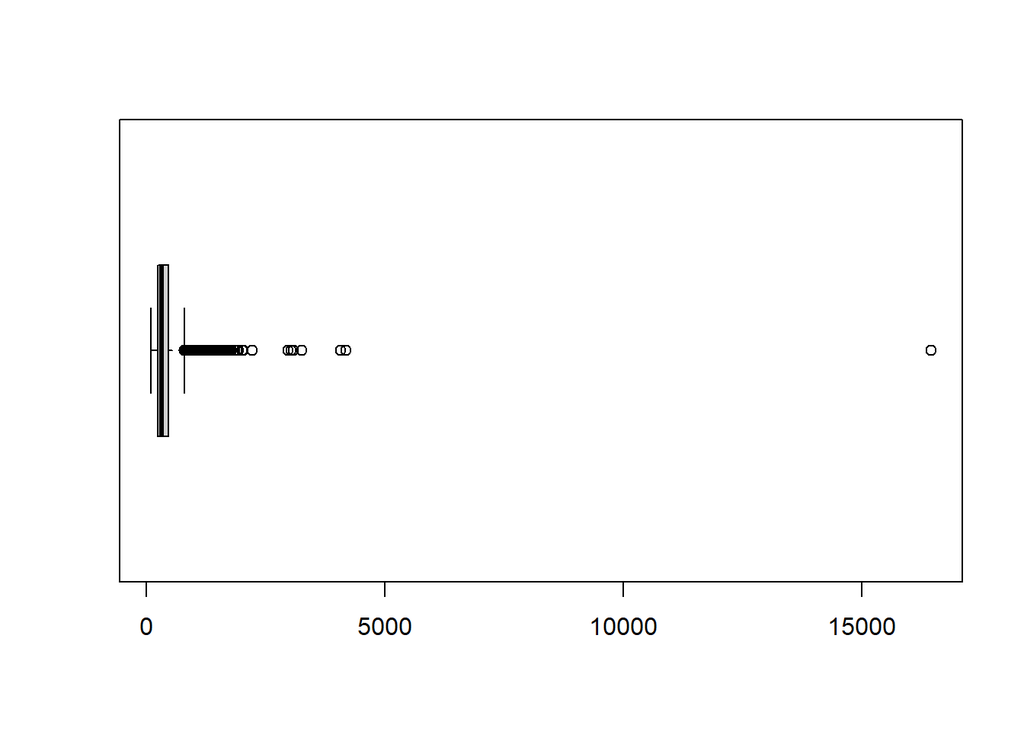

```r
boxplot(PrecioFinal, horizontal = TRUE)
```

Si le quitamos los valores atípicos se vería algo así:

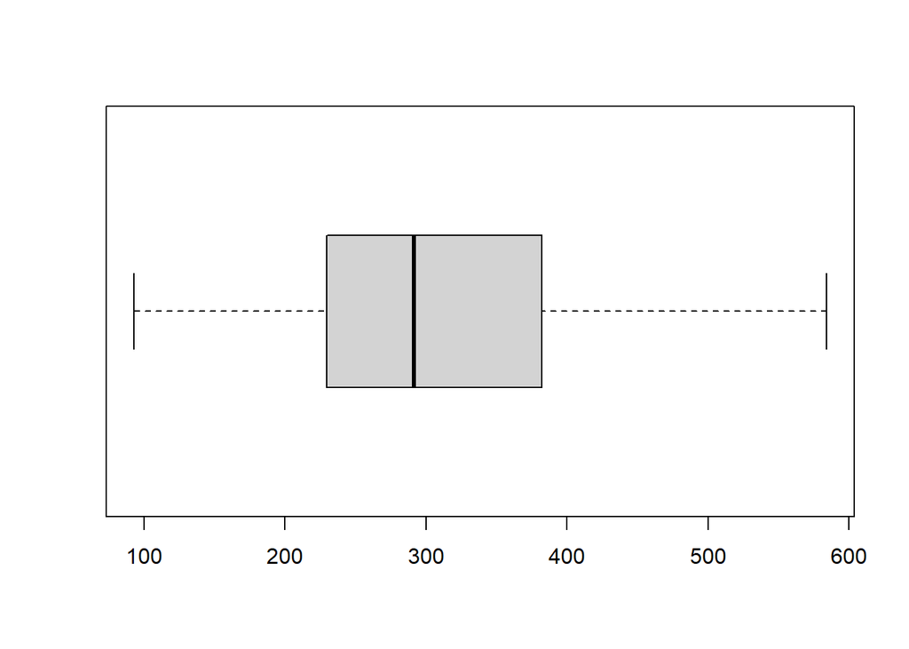

```r
mean_val <- mean(PrecioFinal)
sd_val <- sd(PrecioFinal)
PrecioFinalSinAtipicos <- PrecioFinal[PrecioFinal < (mean_val + 2.1*sd_val) & PrecioFinal > (mean_val - 2.1*sd_val)]
mean_val2 <- mean(PrecioFinalSinAtipicos)
sd_val2 <- sd(PrecioFinalSinAtipicos)
PrecioFinalSinAtipicos2 <- PrecioFinalSinAtipicos[PrecioFinalSinAtipicos < (mean_val2 + 2.1*sd_val2) & PrecioFinalSinAtipicos > (mean_val2 - 2.1*sd_val2)]
mean_val3 <- mean(PrecioFinalSinAtipicos2)
sd_val3 <- sd(PrecioFinalSinAtipicos2)
PrecioFinalSinAtipicos3 <- PrecioFinalSinAtipicos2[PrecioFinalSinAtipicos2 < (mean_val3 + 2.1*sd_val3) & PrecioFinalSinAtipicos2 > (mean_val3 - 2.1*sd_val3)]
mean_val4 <- mean(PrecioFinalSinAtipicos3)
sd_val4 <- sd(PrecioFinalSinAtipicos3)
PrecioFinalSinAtipicos4 <- PrecioFinalSinAtipicos3[PrecioFinalSinAtipicos3 < (mean_val4 + 2.1*sd_val4) & PrecioFinalSinAtipicos3 > (mean_val4 - 2.1*sd_val4)]
boxplot(PrecioFinalSinAtipicos4, horizontal = TRUE)
```

*Mínimo:*

```
## [1] 92.7393
```

*Máximo:*

```
## [1] 584.1644
```

*Rango:*

```
## [1] 491.4251
```

*Media:*

```
## [1] 311.4403
```

*Desviación estándar:*

```
## [1] 111.7408
```

Aqui podemos ver que la desviacion estadar es mayor a 20 por lo tanto la media no es representativa para en este caso, por lo que la variable representativa seria la mediana.

*Coeficiente de variación:*

```
## [1] 0.3587872
```

*Cuartiles 1 y 3:*

```
## [1] 229.5181
```

```
## [1] 382.3749
```

*Rango intercuartil*

```
## [1] 152.8567
```

*Cerco inferior y superior:*

```
## [1] 0.2330133
```

```
## [1] 611.66
```

*Curtosis*

```
## [1] 2.518782
```

*coeficiente de simetria*

```
## [1] 0.4904623
```

Vemos que el valor de este coeficiente es positivo, podemos decir que esta variable tiene una asimetria hacia la derecha. *tabla de frecuencia*

```r
preciof <- cut(PrecioFinalSinAtipicos4, c(seq(from = 90, to = 600, by = 100)), include.lowest=TRUE)
tabla.2 <- freq(ordered(preciof))
```

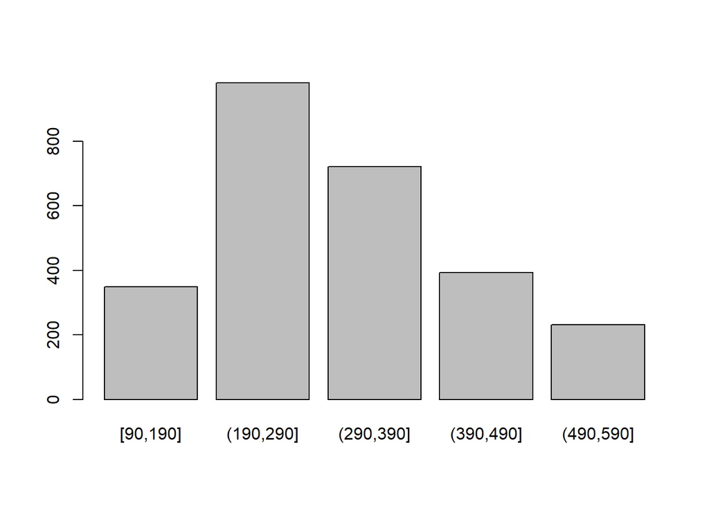

```r
tabla.2
```

```
## ordered(preciof)
##           Frequency Percent Cum Percent
## [90,190]        349   13.04       13.04
## (190,290]       981   36.66       49.70
## (290,390]       721   26.94       76.64
## (390,490]       393   14.69       91.33
## (490,590]       232    8.67      100.00
## Total          2676  100.00
```

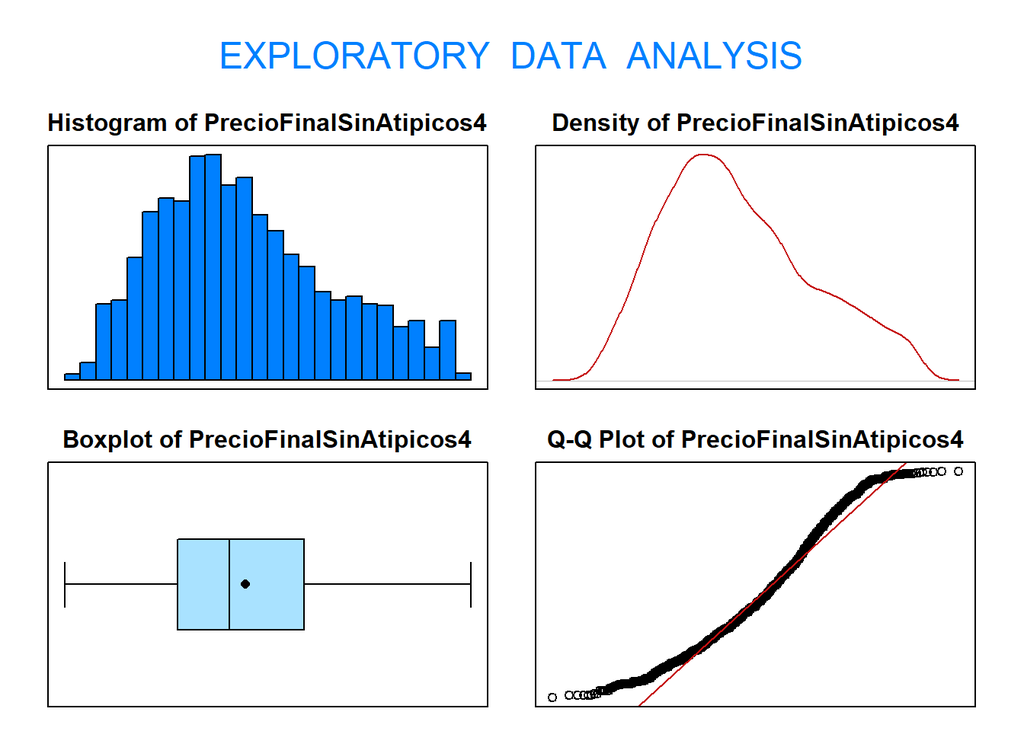

```
##  Size (n)   Missing   Minimum    1st Qu      Mean    Median    TrMean    3rd Qu
##  2676.000     0.000    92.739   229.518   311.440   291.616   307.960   382.375
##       Max     Stdev       Var   SE Mean    I.Q.R.     Range  Kurtosis  Skewness
##   584.164   111.741 12485.998     2.160   152.857   491.425    -0.483     0.490
##  SW p-val
##     0.000
```

```r
eda(PrecioFinalSinAtipicos4)
```

### **Capacidad de personas**

*Mínimo:*

```
## [1] 2
```

*Máximo:*

```
## [1] 6
```

*Rango:*

```
## [1] 4
```

*Media:*

```
## [1] 2.947284
```

*Desviación estándar:*

```
## [1] 1.225632
```

Vemos que la desviacion estandar es menor a 20, por lo que podemos decir que la media si es representativa en esta distribucion

*Coeficiente de variación:*

```
## [1] 0.4158513
```

*Cuartiles 1 y 3:*

```
## [1] 2
```

```
## [1] 4
```

*Rango intercuartil*

```
## [1] 2
```

*Coeficiente de asimetría*

```
## [1] 1.020291
```

Como el valor de este coeficiente es positivo, podemos decir que esta variable tiene una asimetria hacia la derecha

*Cerco inferior y superior:*

```
## [1] -1
```

```
## [1] 7
```

*Curtosis*

```
## [1] 2.985628
```

*Gráfico de barras*

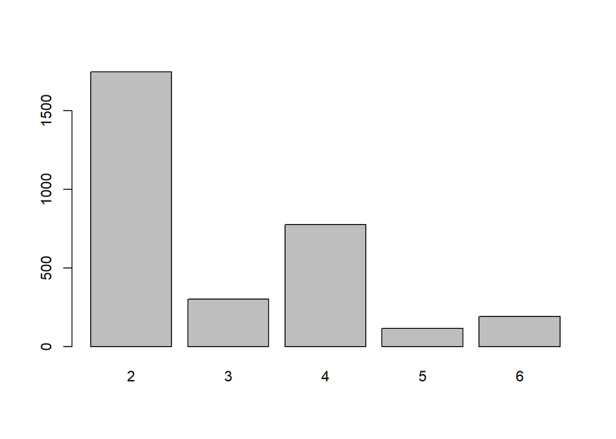

*Tabla de frecuencias*

```r
tabla.2
```

```
## ordered(CapacidadPersonas)
##       Frequency Percent Cum Percent
## 2          1746  55.783       55.78
## 3           302   9.649       65.43
## 4           775  24.760       90.19
## 5           115   3.674       93.87
## 6           192   6.134      100.00
## Total      3130 100.000
```

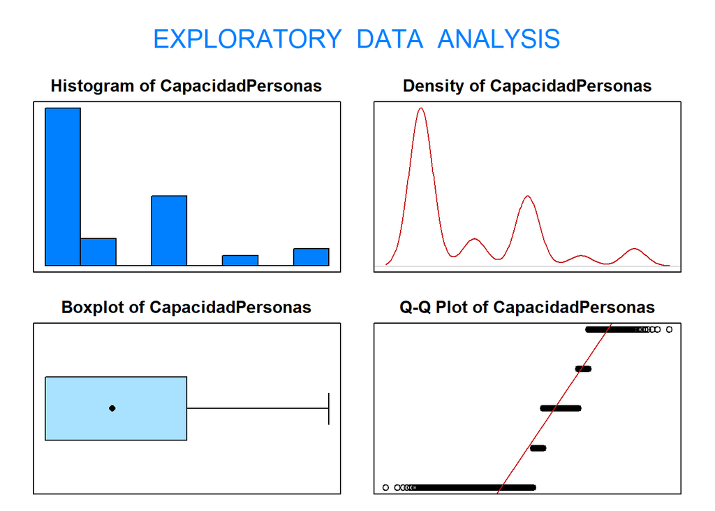

```
## Size (n)  Missing  Minimum   1st Qu     Mean   Median   TrMean   3rd Qu
## 3130.000    0.000    2.000    2.000    2.947    2.000    2.831    4.000
##      Max    Stdev      Var  SE Mean   I.Q.R.    Range Kurtosis Skewness
##    6.000    1.226    1.502    0.022    2.000    4.000   -0.016    1.020
## SW p-val
##    0.000
```

```r
eda(CapacidadPersonas)
```

Vemos que esta distribución no posee datos atipicos por lo que podemos usarla tal cual como está.

### **Distancia al centro de la ciudad**

Se graficara la variable para ver si tiene valores atipicos:

*Diagrama de cajas:*

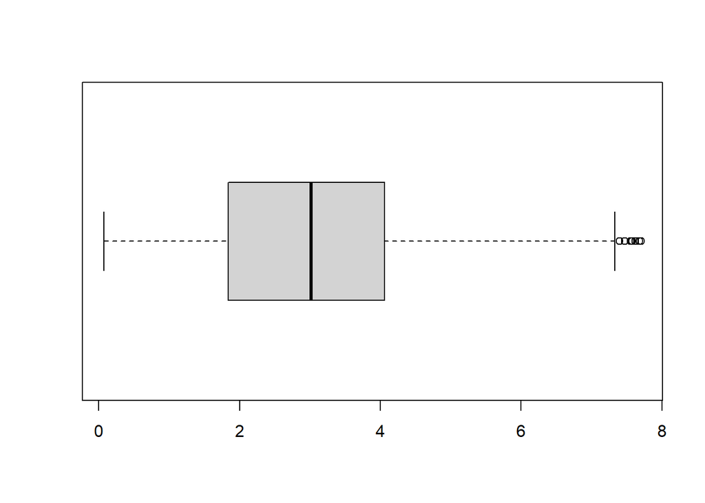

Vemos que en esta distribución se ven que existen varios atipicos por lo que los vamos a quitar

*Datos Atipicos*

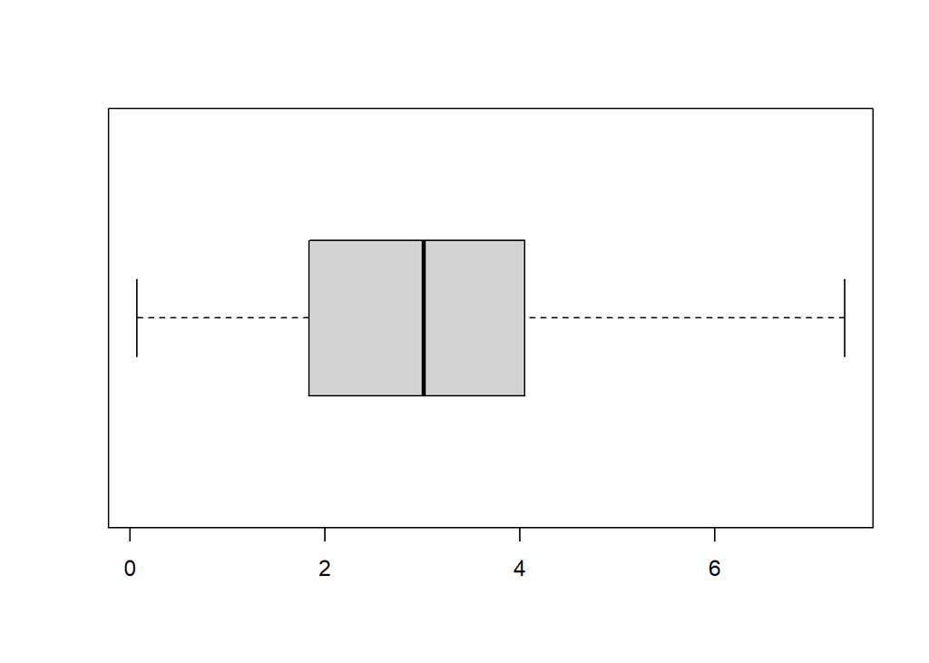

*Media:*

```
## [1] 2.999174
```

*Desviación estándar:*

```
## [1] 1.455105
```

*Mínimo:*

```
## [1] 0.07154323
```

*Máximo:*

```
## [1] 7.328988
```

*Rango:*

```
## [1] 7.257444
```

*Coeficiente de variación:*

```
## [1] 0.4851684
```

*Cuartiles 1 and 3:*

```
## [1] 1.840171
```

```
## [1] 4.051042
```

*Rango intercuartil*

```
## [1] 2.210871
```

*Cerco inferior y superior:*

```
## [1] -1.476135
```

```
## [1] 7.367347
```

*Curtosis:*

```
## [1] 2.477619
```

*Coeficiente de simetria:*

```
## [1] 0.2522531
```

Este coeficiente nos dice que tiene una asimetria positiva, por lo que nos dice que la distribucion tiene una cola derecha mas larga que la izquierda

*Tabla de frecuencia* *grafico de barras*

```r
rangos <- cut(DistanciaCentroSinAtipicos,  c(seq(from = 0, to =7 , by = 2),8), include.lowest=TRUE)

tabla_frecuenciaD <- table(rangos)
print(tabla_frecuenciaD)
```

```
## rangos
## [0,2] (2,4] (4,6] (6,8]
##   900  1409   748    65
```

```r
tabla.D <- freq(ordered(rangos))
```

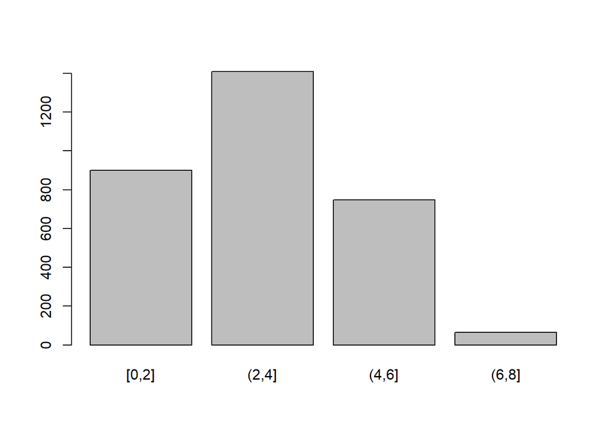

```r
tabla.D
```

```
## ordered(rangos)
##       Frequency Percent Cum Percent
## [0,2]       900  28.828       28.83
## (2,4]      1409  45.131       73.96
## (4,6]       748  23.959       97.92
## (6,8]        65   2.082      100.00
## Total      3122 100.000
```

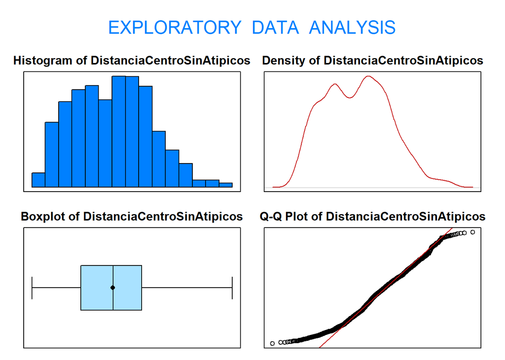

```
## Size (n)  Missing  Minimum   1st Qu     Mean   Median   TrMean   3rd Qu
## 3122.000    0.000    0.072    1.840    2.999    3.015    2.963    4.051
##      Max    Stdev      Var  SE Mean   I.Q.R.    Range Kurtosis Skewness
##    7.329    1.455    2.117    0.026    2.211    7.257   -0.524    0.252
## SW p-val
##    0.000
```

```r
eda(DistanciaCentroSinAtipicos)
```

## **Estadística descriptiva variables cualitativas**

### **Tipo de cuarto**

Generamos una tabla de frecuencias

```
##         categoria frec. abs  frec. rel frec. rel. acum
## 1 Entire home/apt      2325 0.74281150       0.7428115
## 2    Private room       758 0.24217252       0.9849840
## 3     Shared room        47 0.01501597       1.0000000
```

Ahora calculamos la moda

```
## [1] "Entire home/apt"
```

*Diagrama de barras*

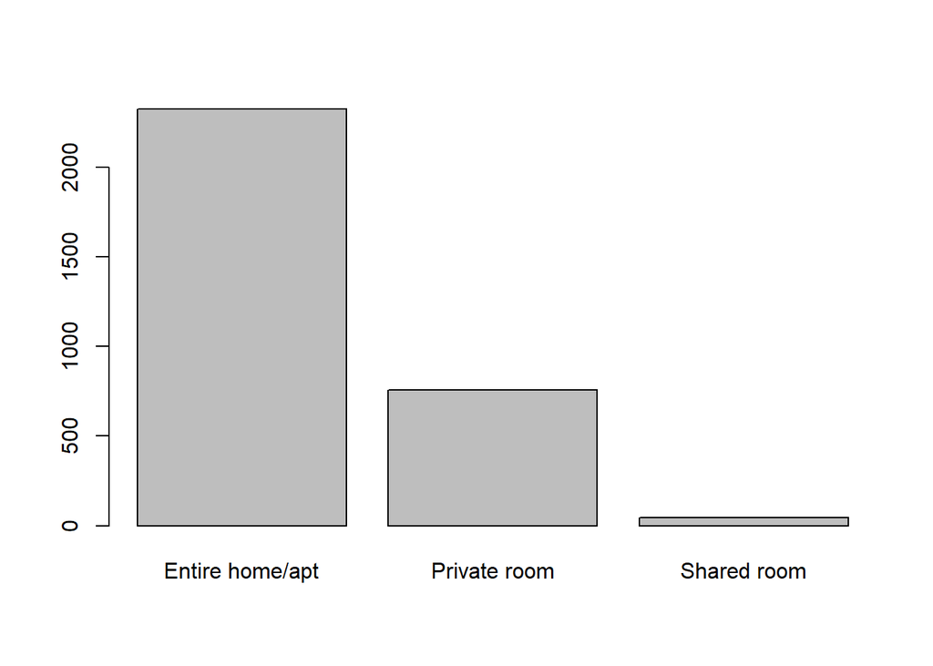

```r
barplot(table(TipoDeCuarto))
```

### **Cuarto privado**

Generamos una tabla de frecuencias

```
##   categoria frec. abs frec. rel frec. rel. acum
## 1     FALSE      2372 0.7578275       0.7578275
## 2      TRUE       758 0.2421725       1.0000000
```

Ahora calculamos la moda

```
## [1] "FALSE"
```

*Gráfico de pastel:*

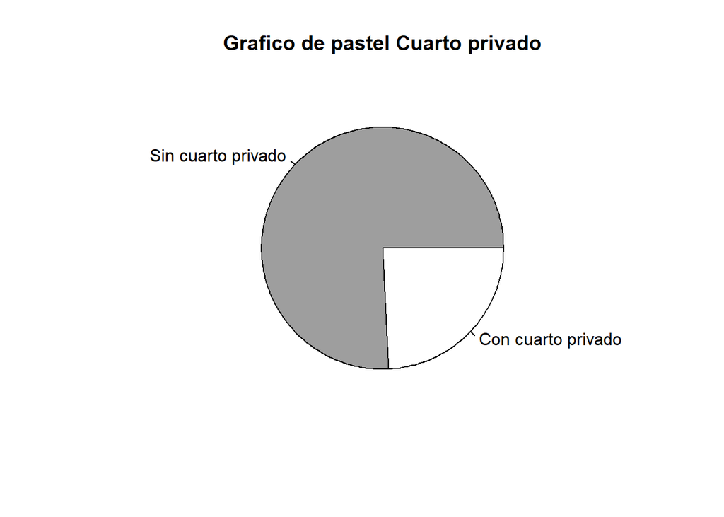

### **Múltiples cuartos**

Generamos una tabla de frecuencias

```
##   categoria frec. abs frec. rel frec. rel. acum
## 1         0      2426 0.7750799       0.7750799
## 2         1       704 0.2249201       1.0000000
```

Ahora calculamos la moda

```
## [1] "0"
```

*Gráfico de pastel:*

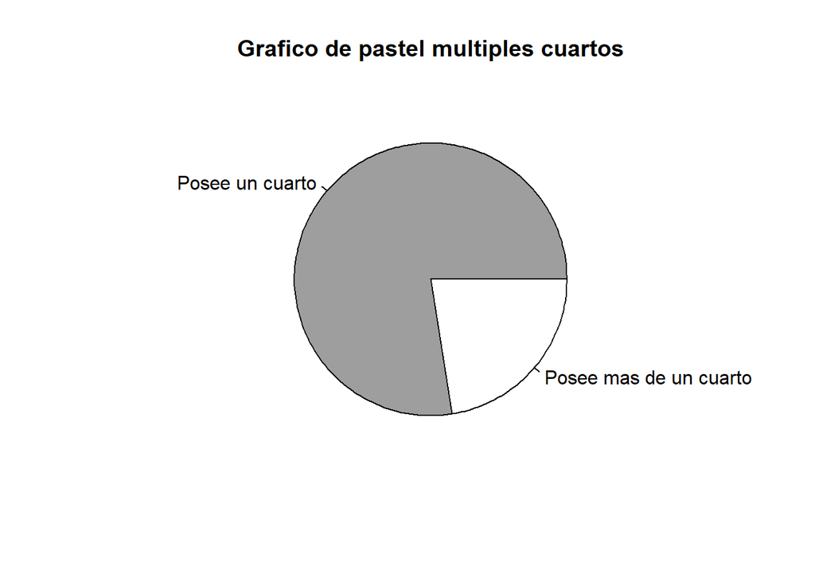

### **Fines de negocios**

*Generamos una tabla de frecuencias*

```
##   categoria frec. abs frec. rel frec. rel. acum
## 1         0      2322  0.741853        0.741853
## 2         1       808  0.258147        1.000000
```

*Ahora calculamos la moda*

```
## [1] "0"
```

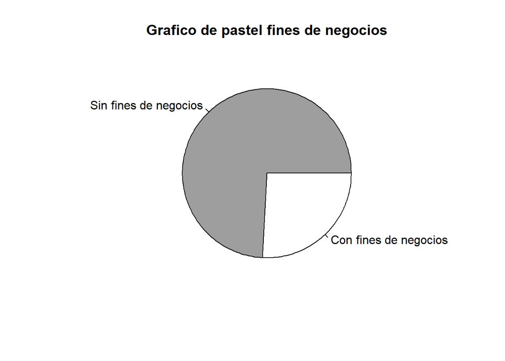

$$$$

## **Análisis de resultados**

Para esta sección se van a estimar parámetros de interés a través de intervalos de confianza para cada una de las variables, ya sea para la media poblacional o la proporción. Así mismo, se van a realizar pruebas de hipótesis para la media y la proporción. $$$$

### **Intervalos de confianza**

Para estimar los intervalos de confianza, tenemos en cuenta que la base de datos que tenemos es una muestra de toda la población de alojamientos de París en Airbnb entre semana. Por lo tanto, para cada una de estas estimaciones, vamos a utilizar las fórmulas de la distribución t-Student, ya que no contamos con la desviación estándar poblacional.

$$$$

#### **Variables cuantitativas**

##### **Calificación de limpieza**

*Ahora calculamos la media muestral*

```r
mediaMuestral <- mean(CalificacionDeLimpieza)
mediaMuestral
```

```
## [1] 9.253994
```

*Calculamos la desviación muestral*

```r
desviacionestándarMuestral <- sd(CalificacionDeLimpieza)
desviacionestándarMuestral
```

```
## [1] 0.987793
```

Dentro de la estimación vamos a tomar el nivel de confianza como 98%. y vamos a aplicar la siguiente ecuación:

$$\bar{x} \pm t_{\alpha/2, n-1}
\frac{s}{\sqrt{n}}$$

*Ahora hacemos la estimación*

```r
rango_inferior <- mediaMuestral+qt(0.01, df=length(CalificacionDeLimpieza)-1)*(desviacionestándarMuestral/sqrt(length(CalificacionDeLimpieza)))
rango_inferior
```

```
## [1] 9.212898
```

```r
rango_Superior <- mediaMuestral-qt(0.01, df=length(CalificacionDeLimpieza)-1)*(desviacionestándarMuestral/sqrt(length(CalificacionDeLimpieza)))
rango_Superior
```

```
## [1] 9.295089
```

Con estos valores obtenemos el siguiente rango:

$$[9.21~; ~9.30]$$
Es decir que el puntaje de limpieza promedio de los Airbnb en París entre semana con un 98% de confianza está dentro del rango de los 9.21 puntos a los 9.30 puntos.

$$$$

###### **Precio Final**

*Ahora calculamos la media muestral*

```r
mediaMuestral <- mean(PrecioFinal)
mediaMuestral
```

```
## [1] 398.7867
```

*Calculamos la desviación muestral*

```r
desviacionestándarMuestral <- sd(PrecioFinal)
desviacionestándarMuestral
```

```
## [1] 396.368
```

Dentro de la estimación vamos a tomar el nivel de confianza como 95%. y vamos a aplicar la siguiente ecuación:

$$\bar{x} \pm t_{\alpha/2, n-1}
\frac{s}{\sqrt{n}}$$

*Ahora hacemos la estimación*

```r
rango_inferior <- mediaMuestral+qt(0.025, df=length(PrecioFinal))*(desviacionestándarMuestral/sqrt(length(PrecioFinal)))
rango_inferior
```

```
## [1] 384.8954
```

```r
rango_Superior <- mediaMuestral-qt(0.025, df=length(PrecioFinal))*(desviacionestándarMuestral/sqrt(length(PrecioFinal)))
rango_Superior
```

```
## [1] 412.678
```

Con estos valores obtenemos el siguiente rango:

$$[384.90~; ~412.69]$$
Es decir, que el precio promedio de los Airbnb en París entre semana, con un 95% de confianza, está dentro del rango 384,90 y 412,69 Euros.

$$$$

##### **Capacidad de personas**

*Ahora calculamos la media muestral*

```r
mediaMuestral <- mean(CapacidadPersonas)
mediaMuestral
```

```
## [1] 2.947284
```

*Calculamos la desviación muestral*

```r
desviacionestándarMuestral <- sd(CapacidadPersonas)
desviacionestándarMuestral
```

```
## [1] 1.225632
```

Dentro de la estimación vamos a tomar el nivel de confianza como 95%. y vamos a aplicar la siguiente ecuación:

$$\bar{x} \pm t_{\alpha/2, n-1}
\frac{s}{\sqrt{n}}$$

*Ahora hacemos la estimación*

```r
rango_inferior <- mediaMuestral+qt(0.025, df=length(CapacidadPersonas))*(desviacionestándarMuestral/sqrt(length(CapacidadPersonas)))
rango_inferior
```

```
## [1] 2.90433
```

```r
rango_Superior <- mediaMuestral-qt(0.025, df=length(CapacidadPersonas))*(desviacionestándarMuestral/sqrt(length(CapacidadPersonas)))
rango_Superior
```

```
## [1] 2.990238
```

Con estos valores obtenemos el siguiente rango:

$$[2.90~; ~2.99]$$
Es decir, que la capacidad promedio de personas de los AirBnB en París entre semana, con un 95% de confianza, está dentro del rango de 2,9 a 2,99 personas.

$$$$

##### **Distancia al centro de la ciudad**

*Ahora calculamos la media muestral*

```r
mediaMuestral <- mean(DistanciaCentro)
mediaMuestral
```

```
## [1] 3.010861
```

*Calculamos la desviación muestral*

```r
desviacionestándarMuestral <- sd(DistanciaCentro)
desviacionestándarMuestral
```

```
## [1] 1.47148
```

Dentro de la estimación vamos a tomar el nivel de confianza como 98%. y vamos a aplicar la siguiente ecuación:

$$\bar{x} \pm t_{\alpha/2, n-1}
\frac{s}{\sqrt{n}}$$

*Ahora hacemos la estimación*

```r
rango_inferior <- mediaMuestral+qt(0.01, df=length(DistanciaCentro))*(desviacionestándarMuestral/sqrt(length(DistanciaCentro)))
rango_inferior
```

```
## [1] 2.949643
```

```r
rango_Superior <- mediaMuestral-qt(0.01, df=length(DistanciaCentro))*(desviacionestándarMuestral/sqrt(length(DistanciaCentro)))
rango_Superior
```

```
## [1] 3.072079
```

Con estos valores obtenemos el siguiente rango:

$$[2.94~; ~3.07]$$
Es decir, que la distancia promedio al centro de los Airbnb en París entre semana, con un 98% de confianza, está dentro del rango de 2.94 kilómetros a 3.07 kilómetros.

$$$$

### **Variables cualitativas**

$$$$

##### **Tipo de cuarto**

Para esta variable vamos a calcular los intervalos en que cada uno de los posibles tipos de cuartos estén, cada uno con un nivel de confianza del 95%:

```r
# Calcular la proporción de cada categoría en los datos
proporciones <- table(TipoDeCuarto) / length(TipoDeCuarto)

# Calcular el error estándar de cada proporción
error_estándar <- sqrt(proporciones * (1 - proporciones) / length(TipoDeCuarto))

# Calcular el intervalo de confianza del 95% para cada proporción
intervalos_confianza_inferiores <- proporciones + qt(0.025, length(TipoDeCuarto)) * error_estándar
intervalos_confianza_superiores <- proporciones - qt(0.025, length(TipoDeCuarto)) * error_estándar

# Imprimir el resultado
cat("Los intervalos de confianza del 95% son:")
```

```
## Los intervalos de confianza del 95% son:
```

```r
for (i in 1:length(proporciones)) {
  cat("\n - Categoría '", names(proporciones)[i], "': [", intervalos_confianza_inferiores[i], ", ", intervalos_confianza_superiores[i], "]", sep="")
}
```

```
##
##  - Categoría 'Entire home/apt': [0.7274933, 0.7581297]
##  - Categoría 'Private room': [0.2271587, 0.2571864]
##  - Categoría 'Shared room': [0.01075376, 0.01927819]
```

Con esto, podemos decir que los rangos de confianza de la proporción de los valores son los siguientes:

- **Casa/ Apartamento entero:** $[0.73, 0.76]$, es decir entre 73% al 76%
- **Cuarto Privado** $[0.23, 0.26]$, es decir entre 23% al 26%
- **Cuarto compartido** $[0.01, 0.02]$, es decir entre 1% al 2%

$$$$

##### **Cuarto privado**

*Buscamos la proporción de esta y tomamos los alojamientos con cuarto privado*

```r
datos_true <- subset(CuartoPrivado, CuartoPrivado == TRUE)
privateRoomTrue <- sum(CuartoPrivado)
privateRoomTrue
```

```
## [1] 758
```

*Se hara la estimación para los alojamientos que cuentan con cuarto privado*

```r
p <- privateRoomTrue/length(CuartoPrivado)
p
```

```
## [1] 0.2421725
```

*Finalmente usamos el siguiente código para estimar la proporción con una confianza del 95%*

```r
rango_inferior <-p + qt(0.025, length(CuartoPrivado))* sqrt((p*(1-p))/length(CuartoPrivado))
rango_inferior
```

```
## [1] 0.2271587
```

```r
rango_superior <-  p - qt(0.025, length(PoseeMasDeUnCuarto))* sqrt((p*(1-p))/length(CuartoPrivado))
rango_superior
```

```
## [1] 0.2571864
```

*Escribimos el intervalo caluculado anteriormente:*

$$[0.23, 0.26]$$

*Con una confianza al 95% podemos decir que la proporción de los alojamientos que poseen cuarto privado es mayor o igual que 0,23 y menor o igual a 0,26, o del 23% al 26%*

$$$$

##### **Multiples cuartos**

*Buscamos la proporción de esta y tomamos los alojamientos con más de un cuarto*

```r
datos_true <- subset(PoseeMasDeUnCuarto, PoseeMasDeUnCuarto == 1)
multi <- sum(datos_true)
multi
```

```
## [1] 704
```

*Se hara la estimación para los alojamientos que cuentan con más de un cuarto*

```r
p <- multi/length(PoseeMasDeUnCuarto)
p
```

```
## [1] 0.2249201
```

*Finalmente usamos el siguiente código para estimar la proporción con una confianza del 95%*

```r
rango_inferior <- p + qt(0.025, length(PoseeMasDeUnCuarto))* sqrt((p*(1-p))/length(PoseeMasDeUnCuarto))
rango_inferior
```

```
## [1] 0.2102872
```

```r
rango_superior <- p - qt(0.025, length(PoseeMasDeUnCuarto))* sqrt((p*(1-p))/length(PoseeMasDeUnCuarto))
rango_superior
```

```
## [1] 0.2395531
```

*Escribimos el intervalo calculado anteriormente:*

$$$$

##### **Fines de negocios**

*Buscamos la proporción de esta y tomamos los alojamientos que son con fines de negocios*

```r
# <- subset(FinesDeNegocios, FinesDeNegocios == 1)
#multi <- sum(datos_true)
#multi
```

```r
p <- multi/length(FinesDeNegocios)
p
```

```
## [1] 0.2249201
```

*Finalmente usamos el siguiente código para estimar la proporción con una confianza del 95%*

```r
rango_inferior <- p + qt(0.025, length(FinesDeNegocios))* sqrt((p*(1-p))/length(FinesDeNegocios))
rango_inferior
```

```
## [1] 0.2102872
```

```r
rango_superior <- p - qt(0.025, length(FinesDeNegocios))* sqrt((p*(1-p))/length(FinesDeNegocios))
rango_superior
```

```
## [1] 0.2395531
```

$$$$

### **Hipótesis para las variables**

Dentro de esta sección del estudio vamos a plantear hipótesis a las variables, ya sea respecto a la media o a la proporción, dependiendo de su caracteristica cualitativa o cuantitiva. Para realizar esto vamos a utilizar como base para plantear nuestras hipotesis los datos de AirBnb en Roma durante los dias entresemana, a partir de esto vamos a comprobar si se cumplen dichas hipotesis dentro de los Airbnb de Paris durante los dias entre semana.

Importamos los datos de AirBnb Roma entre semana:

```r
rome_weekdays <- read_csv("rome_weekdays.csv")
```

```
## ──────────────────────────────────────────────────────── Delimiter: "," chr
## (1): room_type dbl (16): ...1, realSum, person_capacity, multi, biz,
## cleanliness_rating, gu... lgl (3): room_shared, room_private, host_is_superhost
```

```r
#Variables cuantitativas
CalificacionDeLimpiezaRoma <- rome_weekdays$cleanliness_rating
PrecioFinalRoma <- rome_weekdays$realSum
CapacidadPersonasRoma <- rome_weekdays$person_capacity
DistanciaCentroRoma <- rome_weekdays$dist

#Variables cualitativas
TipoDeCuartoRoma <-  rome_weekdays$room_type
CuartoPrivadoRoma <- rome_weekdays$room_private
PoseeMasDeUnCuartoRoma <- rome_weekdays$multi
FinesDeNegociosRoma <- rome_weekdays$biz
```

$$$$

#### **Variables cuantitativas**

##### **Puntaje de limpieza**

Para la plataforma Airbnb es de gran imporancia la calificación de la limpieza de sus alojamientos, es por esto que se espera que la mayoría de sus alojamientos posean un buen puntaje de limpieza. Para poder plantear la hipotesis vamos a mirar cual es la media muestral de los Airbnb en Roma:

```r
mean(CalificacionDeLimpiezaRoma)
```

```
## [1] 9.516028
```

Vemos que su calificacion promedio es 9.52. Ahora queremos saber si el puntaje de limpieza en Paris es igual a 9.52, por lo que podemos plantear las siguientes hipotesis:

- $H_0: \mu = 9.52$
- $H_1: \mu \neq 9.52$

*Usamos el siguiente código para encontrar el valor de p:*

```r
with(datos, (t.test(CalificacionDeLimpieza, alternative = "two.sided", mu = 9.52, conf.level = 0.95)))
```

```
##
##  One Sample t-test
##
## data:  CalificacionDeLimpieza
## t = -15.066, df = 3129, p-value < 2.2e-16
## alternative hypothesis: true mean is not equal to 9.52
## 95 percent confidence interval:
##  9.219375 9.288612
## sample estimates:
## mean of x
##  9.253994
```

Con el resultado anterior podemos observar como $p < 0.05$, sabiendo esto, podemos rechazar la hipótesis nula y podemos afirmar que con un nivel de confianza del 95%, la calificación media de los alojamientos de Airbnb en la ciudad de París es diferente a 9.52.

##### **Precio final**

Sin duda los Airbnb en Paris quieren brindar la mejor atencion a sus clientes con los precios mas justos de acuerdo a su experiencia, por lo tanto van a comparar con Airbnb en Roma para poder establecer un punto de comparacion:

```r
mean(PrecioFinalRoma)
```

```
## [1] 201.6181
```

Como vemos la media de precios en roma es de 201, por lo tanto, vamor a plantear las siguientes hipótesis:

- $H_0: \mu \leq 201$
- $H_1: \mu > 201$

*Aplicamos el siguiente código para comprobar nuestras hipótesis:*

```r
with(datos, (t.test(PrecioFinalSinAtipicos4, alternative = "greater", mu =201, conf.level = 0.95)))
```

```
##
##  One Sample t-test
##
## data:  PrecioFinalSinAtipicos4
## t = 51.128, df = 2675, p-value < 2.2e-16
## alternative hypothesis: true mean is greater than 201
## 95 percent confidence interval:
##  307.886     Inf
## sample estimates:
## mean of x
##  311.4403
```

Vemos que el valor p es bastante pequeño, (menor al 0.05) asi que podemos rechazar esta hipotesis nula y podemos concluir que los Airbnb en paris tiene un precio mayor a 201 Euros.

##### **Capacidad de personas**

La capacidad de personas que caben dentro de un alojamiento es sumamente importante en la industria de Airbnb. En la ciudad de Roma se realizo un estudio que concluyo en que la capacidad media es de 3.35 personas por alojamiento. Se desea saber si, con un nivel de confianza del 95%, se cumple como hipótesis nula que la capacidad de personas promedio es mayor o igual que la capacidad de personas promedio de Roma.

Planteamos las siguientes hipótesis:

- $H_0: \mu \geq 3.35$
- $H_1: \mu < 3.35$

*Aplicamos el siguiente código para comprobar nuestras hipótesis:*

```r
with(datos, (t.test(CapacidadPersonas, alternative = "less", mu = 3.35, conf.level = 0.95)))
```

```
##
##  One Sample t-test
##
## data:  CapacidadPersonas
## t = -18.383, df = 3129, p-value < 2.2e-16
## alternative hypothesis: true mean is less than 3.35
## 95 percent confidence interval:
##      -Inf 2.983329
## sample estimates:
## mean of x
##  2.947284
```

##### **Distancia al centro**

Para este punto vamos a tomar como punto referencia la distancia promedio al centro de la ciudad en los AirBnb de Roma para poder plantear nuestro estudios de Paris, a continuacion sacamos ese valor:

```r
mean(DistanciaCentroRoma)
```

```
## [1] 3.044737
```

Se sabe que los alojamientos de Airbnb en Roma tienen una distancia hacia el centro de su ciudad de 3.04 kilómetros. Airbnb en Paris requiere saber si la distancia de sus alojamientos es igual a 3.04 kilometros con respecto a la distancia hacia el centro de Paris. Para esto, se plantean las siguientes hipótesis con un nivel de confianza del 95%:

- $H_0: \mu = 3.04$
- $H_1: \mu \neq 3.04$

Calculamos el valor de p con el siguiente código

```r
with(datos, (t.test(DistanciaCentro, alternative = "two.sided", mu = 3.04, conf.level = 0.95)))
```

```
##
##  One Sample t-test
##
## data:  DistanciaCentro
## t = -1.1079, df = 3129, p-value = 0.268
## alternative hypothesis: true mean is not equal to 3.04
## 95 percent confidence interval:
##  2.959291 3.062431
## sample estimates:
## mean of x
##  3.010861
```

#### **Variables cualitativas**

##### **Tipo de cuarto**

Dentro de la industria de Airbnb está la incertidumbre acerca de la posible proporción de alojamientos que ofrecen el apartamento o la casa completa, ya que esto permite una mayor comodidad y exclusividad al usuario. Para poder sacar un punto de comparacion para nuestro estudio vamos a usar los datos de Roma en esta situacion:

```r
sum(TipoDeCuartoRoma == "Entire home/apt")/ length(TipoDeCuartoRoma)
```

```
## [1] 0.6130899
```

Ahora, gracias a este resultado queremos saber si la proporcion de alojamientos que proporcionan todo la casa o apartamento esta por debajo del 61.3%. A continuación, se muestra una prueba de hipótesis de esta información con un nivel de confianza del 95%:

Planteamos las siguientes hipótesis:

- $H_0: \pi \geq 0.613$
- $H_1: \pi < 0.613$

Para comprobar estas hipótesis utilizamos el siguiente código:

```r
daticos<- prop.test( sum(TipoDeCuarto== "Entire home/apt"), n = length(datos$room_type), p = 0.613, alternative = "less")
daticos
```

```
##
##  1-sample proportions test with continuity correction
##
## data:  sum(TipoDeCuarto == "Entire home/apt") out of length(datos$room_type), null probability 0.613
## X-squared = 221.78, df = 1, p-value = 1
## alternative hypothesis: true p is less than 0.613
## 95 percent confidence interval:
##  0.0000000 0.7556055
## sample estimates:
##         p
## 0.7428115
```

Como podemos ver que el valor p es mayor al valor de confianza que fue de 0.05, por lo tanto, no podemos rechazar la hipótesis nula $H_0$. Es decir, que podemos afirmar que la probabilidad de que los alojamientos de Airbnb ofrezcan todo el apartamento o casa es mayor al 61.3%.

##### **Cuarto Privado**

Los alojamientos de Airbnb Paris son las mas visitadas en el mundo, pues Francia es un pais bastante turistico, y ademas Paris es una de las ciudades que mas turistas recibe en el mundo, debido a esto quieren dar la mejor atencion a sus turistas, pues gran parte vive de estos. Ahora bien, no a todos les alcanza el dinero y les toca compartir, pero ellos desean saber cual es la proporcion de personas que tienen cuarto privado, por esto van a comparar con los Airbnb en Roma:

```r
sum(CuartoPrivadoRoma == "TRUE")/ length(CuartoPrivadoRoma)
```

```
## [1] 0.3853517
```

como podemos ver, la proporcion de personas que poseen un cuarto privado en AirBnb Roma es de 0.38, entonces planteamos las siguientes hipótesis:

- $H_0: \pi \leq 0.38$
- $H_1: \pi > 0.38$

Para esto ejecutamos el siguiente codigo para probar las hipotesis:

```r
daticos<- prop.test(sum(CuartoPrivado[CuartoPrivado== "TRUE"] ), n = length(CuartoPrivado), p = 0.38, alternative = "greater")
daticos
```

```
##
##  1-sample proportions test with continuity correction
##
## data:  sum(CuartoPrivado[CuartoPrivado == "TRUE"]) out of length(CuartoPrivado), null probability 0.38
## X-squared = 251.79, df = 1, p-value = 1
## alternative hypothesis: true p is greater than 0.38
## 95 percent confidence interval:
##  0.2296468 1.0000000
## sample estimates:
##         p
## 0.2421725
```

##### **Multiples cuartos**

Un buen punto de partida para relizar las hipotesis dentro del estudio de esta variable seria usando los datos de Roma, tal como lo hicimos anteriormente con las otras variables:

```r
sum(PoseeMasDeUnCuartoRoma == "1")/ length(PoseeMasDeUnCuartoRoma)
```

```
## [1] 0.3866874
```

Podemos tomar como base este resultado y utilizarlo para hacer las hipotesis, por lo que se desea comprobar dicha estimación con un nivel de confianza del 92%. Para esto, se plantean las siguientes hipótesis:

- $H_0: \pi \geq 0.39$
- $H_1: \pi < 0.39$

```r
daticos<- prop.test(sum(datos$multi[datos$multi== "1"] ), n = length(datos$multi), p = 0.39, alternative = "less", conf.level = 0.92)
daticos
```

```
##
##  1-sample proportions test with continuity correction
##
## data:  sum(datos$multi[datos$multi == "1"]) out of length(datos$multi), null probability 0.39
## X-squared = 357.85, df = 1, p-value < 2.2e-16
## alternative hypothesis: true p is less than 0.39
## 92 percent confidence interval:
##  0.00000 0.23574
## sample estimates:
##         p
## 0.2249201
```

##### **Fines de negocios**

Para poder plantear las hipotesis nos basamos en las estadisticas de Roma tal como lo hicimos en las anteriores hipotesis:

```r
mean(FinesDeNegociosRoma)
```

```
## [1] 0.329252
```

Para este caso se desea comprobar si en Paris se cumple que menos del 33% de los alojamientos es para fines de negocios, para dicha estimación vamos a usar un nivel de confianza del 92%. Para esto se plantean las siguientes hipótesis:

- $H_0: \pi \geq 0.33$
- $H_1: \pi < 0.33$

```r
daticos<- prop.test(sum(datos$biz[datos$biz== "1"] ), n = length(datos$biz), p = 0.33, alternative = "less", conf.level = 0.92)
daticos
```

```
##
##  1-sample proportions test with continuity correction
##
## data:  sum(datos$biz[datos$biz == "1"]) out of length(datos$biz), null probability 0.33
## X-squared = 72.763, df = 1, p-value < 2.2e-16
## alternative hypothesis: true p is less than 0.33
## 92 percent confidence interval:
##  0.0000000 0.2694494
## sample estimates:
##        p
## 0.258147
```

### **Hipotesis para varias variables**

Dentro de esta seccion se van a comparar tanto la media o la proporcion de 2 variables cruzadas dentro de nuestro estudio para poder sacar conclusiones sobre estas: $$$$

#### **Precios del AirBnb de acuerdo al si el cuarto es compartido**

Dentro de este estudio queremos saber como varian sus precios los AirBnb de acuerdo a si el cuarto es compartido o no, por lo que vamos a plantear las siguientes hipotesis:

$$H_0: \mu_1 \leq \mu_2$$

$$H_1: \mu_1 > \mu_2$$

Siendo:

- $\mu_1$: Media de precios de Airbnb en paris con cuarto compartido
- $\mu_2$: Media de precios de Airbnb en paris con cuarto no compartido

```r
datosC1 <- subset(datos,room_shared=="TRUE")
datosC2 <- subset(datos,room_shared=="FALSE")
```

Para comprobar esto primero debemos plantear hipotesis de varianzas y poder ver si podemos tomar varianzas iguales o diferentes, por lo que vamos a plantear las siguientes hipotesis:

$$H_0: \sigma_1^2 =
\sigma_2^2$$

$$H_1: \sigma_1^2 \neq \sigma_2^2$$
Siendo:

- $\sigma_1^2$: Varianza de precio de Airbnb en paris con cuarto compartido
- $\sigma_2^2$: Varianza de precio de Airbnb en paris con cuarto no compartido

```r
var.test(datosC1$realSum,datosC2$realSum, alternative = "two.sided",conf.level = 0.95)
```

```
##
##  F test to compare two variances
##
## data:  datosC1$realSum and datosC2$realSum
## F = 0.025423, num df = 46, denom df = 3082, p-value < 2.2e-16
## alternative hypothesis: true ratio of variances is not equal to 1
## 95 percent confidence interval:
##  0.01749121 0.04020165
## sample estimates:
## ratio of variances
##         0.02542338
```

Como podemos ver, el valor p es mucho menor que 0.05 por lo tanto podemos **asumir varianzas diferentes**. Ahora, compararemos la media de los precios asumiendo varianzas diferentes:

```r
t.test(datosC1$realSum,datosC2$realSum,
      alternative = "greater",
      mu = 0, paired = FALSE, var.equal = FALSE,
     conf.level = 0.95)
```

```
##
##  Welch Two Sample t-test
##
## data:  datosC1$realSum and datosC2$realSum
## t = -22.459, df = 117.08, p-value = 1
## alternative hypothesis: true difference in means is greater than 0
## 95 percent confidence interval:
##  -282.3475       Inf
## sample estimates:
## mean of x mean of y
##  139.7981  402.7349
```

#### **Capacidad de personas cuando sus habitaciones son privadas o compartidas**

Se desea conocer que relacion tiene media la capacidad de personas cuando las habitaciones cuando son privadas o publicas, es por esto que se plantean las siguientes hipotesis:

$$H_0: \mu_1 \leq \mu_2$$

$$H_1: \mu_1 > \mu_2$$

Siendo:

- $\mu_1$: capacidad media de personas de con cuarto privado
- $\mu_2$: capacidad media de personas con cuarto publico

```r
datosC1 <- subset(datos,room_private=="TRUE")
datosC2 <- subset(datos,room_private=="FALSE")
```

$$H_0: \sigma_1^2 =
\sigma_2^2$$

$$H_1: \sigma_1^2 \neq
\sigma_2^2$$

Siendo:

- $\sigma_1^2$: Varianza de capacidad de personas con cuarto publico
- $\sigma_2^2$: Varianza de capacidad de personas con cuarto privado

```r
var.test(datosC2$person_capacity,datosC1$person_capacity, alternative = "greater",conf.level = 0.95)
```

```
##
##  F test to compare two variances
##
## data:  datosC2$person_capacity and datosC1$person_capacity
## F = 2.8473, num df = 2371, denom df = 757, p-value < 2.2e-16
## alternative hypothesis: true ratio of variances is greater than 1
## 95 percent confidence interval:
##  2.580019      Inf
## sample estimates:
## ratio of variances
##           2.847287
```

Podemos ver como el valor $p$ es mucho menor que 0.05, por lo que podemos asumir varianzas varianzas diferentes. Ahora, compararemos la capacidad media de personas asumiendo varianzas diferentes:

```r
t.test(datosC1$person_capacity,datosC2$person_capacity,
       alternative = "greater",
       mu = 0, paired = FALSE, var.equal = FALSE,
       conf.level = 0.95)
```

```
##
##  Welch Two Sample t-test
##
## data:  datosC1$person_capacity and datosC2$person_capacity
## t = -23.263, df = 2184, p-value = 1
## alternative hypothesis: true difference in means is greater than 0
## 95 percent confidence interval:
##  -0.9413918        Inf
## sample estimates:
## mean of x mean of y
##  2.281003  3.160202
```

### **Cruces de variables**

Dentro de esta sección, de acuerdo a los objetivos planteados al inicio del informe, vamos a comparar diferentes variables entre sí con el fin de buscar algún tipo de relación entre ellas. A continuación se presentan las gráficas que ilustran dicha comparación o cruce.

#### **Tipo de cuarto vs Fines de negocio**

A continuación se muestra una grafica de barras apliladas para mostrar la relación que tienen las variables de tipo de cuarto y alojamiento con fines de negocio

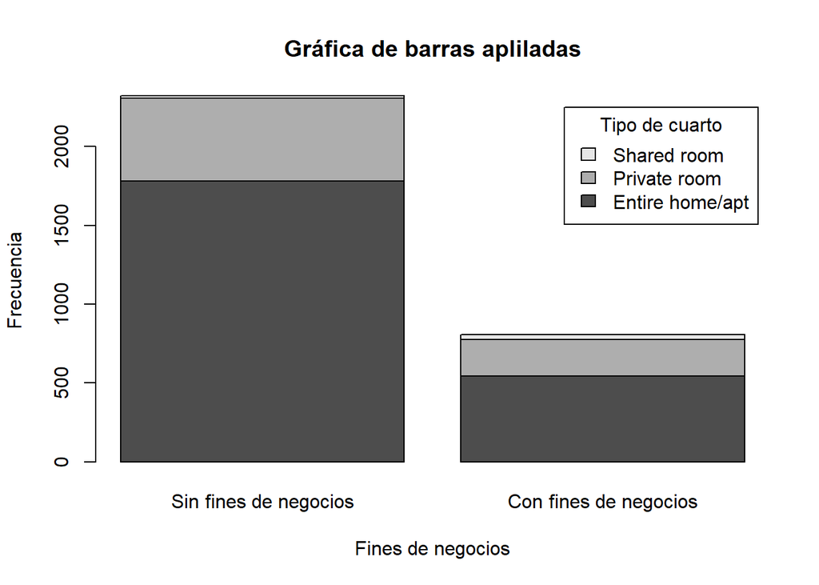

```r
datos <-data.frame(TipoDeCuarto, FinesDeNegocios)
tabla <- table(datos)
barplot(tabla, beside = FALSE,
        main = "Gráfica de barras apliladas",
        xlab = "Fines de negocios", ylab = "Frecuencia",
        names.arg = c("Sin fines de negocios", "Con fines de negocios"),
        legend.text = rownames(tabla),
        args.legend = list(title = "Tipo de cuarto"))
```

En esta grafica podemos observar que asombrosamente los alojamientos con fines de negocios tienen una mayor proporción de cuartos compartidos a comparación de los alojamientos que no fueron para fines de negocios.

#### **Cuarto privado vs Posee mas de un cuarto**

A continuación se muestra una grafica de barras apiladas para mostrar la relación que tienen las variables de cuarto privado y posee mas de un cuarto

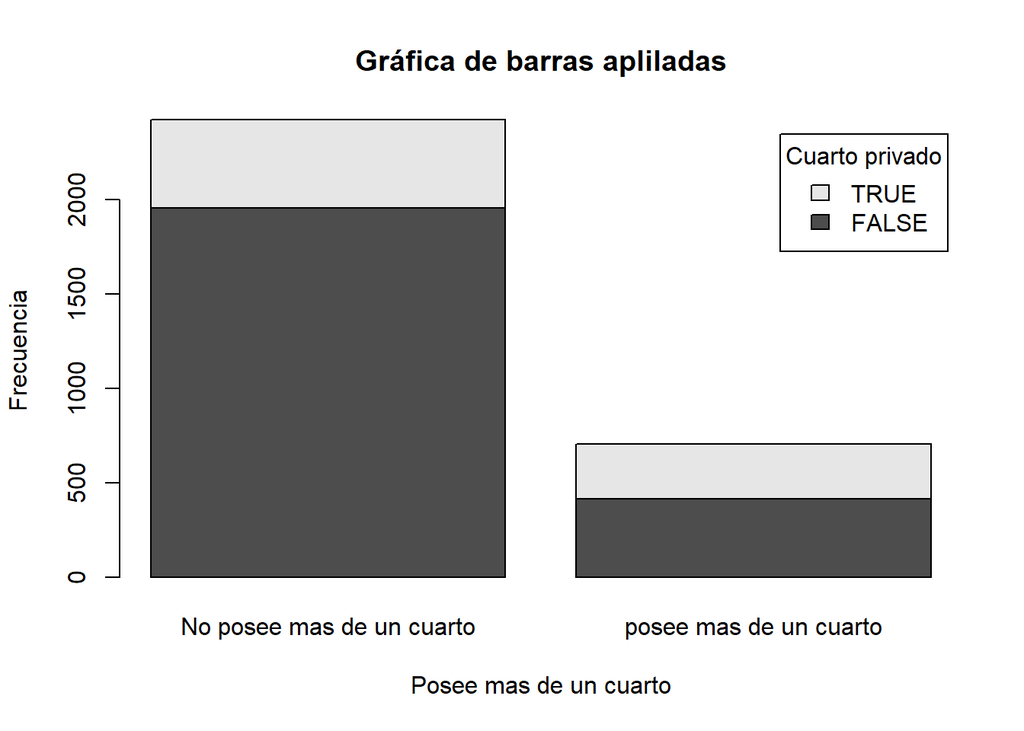

```r
datos <-data.frame(CuartoPrivado, PoseeMasDeUnCuarto)
tabla <- table(datos)
barplot(tabla, beside = FALSE,
        main = "Gráfica de barras apliladas",
        xlab = "Posee mas de un cuarto", ylab = "Frecuencia",
        names.arg = c("No posee mas de un cuarto", "posee mas de un cuarto"),
        legend.text = rownames(tabla),
        args.legend = list(title = "Cuarto privado"))
```

Con esta grafica, a diferencia de los alojamientos que no poseen mas de un cuarto, poco menos de la mitad de los alojamientos que poseen mas de un cuarto poseen cuartos privados.

### **Anova - Análisis de la Varianza**

Dentro de esta seccion del informe vamos a realizar Anova con las diferentes variables que tenemos, sacando secciones a partir de otras variables para comprobar si existen diferencias entre sus medias. A si mismo, en caso de haber un rechazo se procedera a realizar un pos-anova.

$$$$

#### **Compracion del precio teniendo en cuenta su tipo de alojamiento**

Para AirBnb resulta importante poder comparar los diferentes precios que hay de acuerdo con el tipo de alojamiento. Teniendo en cuenta que el tipo de cuarto tiene 3 posibles valores que son : Apartamento/Casa entera, cuarto privado y cuarto compartido, se van a plantear si el precio en cada uno de estos grupos es igual:

$$H_0: \mu_{Completo} = \mu_{Privado} =
\mu_{Compartido}$$

$$H_1:
Al~menos~una~de~ellas~es~diferente$$

Antes de realizar el codigo de anova podemos analizar el comportamiento de los grupos en forma de diagramas de cajas y bigotes:

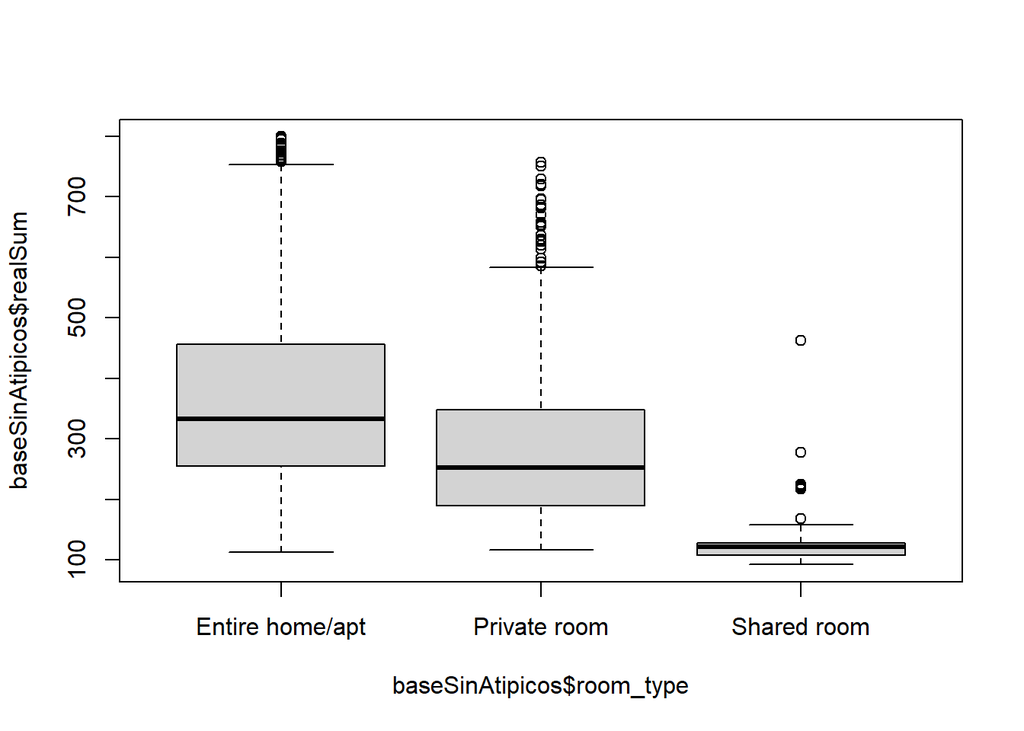

```r
baseSinAtipicos <- filter(Paris_weekdays, Paris_weekdays$realSum < 800)
boxplot(baseSinAtipicos$realSum~baseSinAtipicos$room_type, data = baseSinAtipicos)
```

```r
PrecioFinalSinAtipicos  <- baseSinAtipicos$realSum
TipoDeCuartoSinAtipicos <- baseSinAtipicos$room_type
```

Despues de haber hecho esto si podemos ejecutar el codigo del anova:

*Ejecutamos el codigo de anova:*

```r
anova<-aov(lm(PrecioFinalSinAtipicos~TipoDeCuartoSinAtipicos))
summary(anova)
```

```
##                           Df   Sum Sq Mean Sq F value Pr(>F)
## TipoDeCuartoSinAtipicos    2  5944627 2972314   144.8 <2e-16 ***
## Residuals               2936 60273987   20529
## ---
## Signif. codes:  0 '***' 0.001 '**' 0.01 '*' 0.05 '.' 0.1 ' ' 1
```

Con esto podemos ver que el valor p es mas pequeño que 0.05 por lo que podemos rechazar la hipotesis nula y decir que existen medias diferentes entre los grupos. Por lo que en este caso resulta pertinente realizar un Pos-anova para mirar cual es la relacion entre sus medias:

*Ejecutamos el codigo del Pos-anova*

```r
TukeyHSD(anova)
```

```
##   Tukey multiple comparisons of means
##     95% family-wise confidence level
##
## Fit: aov(formula = lm(PrecioFinalSinAtipicos ~ TipoDeCuartoSinAtipicos))
##
## $TipoDeCuartoSinAtipicos
##                                    diff        lwr        upr p adj
## Private room-Entire home/apt  -84.70765  -99.02531  -70.39000     0
## Shared room-Entire home/apt  -229.29037 -278.82996 -179.75079     0
## Shared room-Private room     -144.58272 -195.12239  -94.04305     0
```

Teniendo en cuenta el criterio del anova podemos decir que el precio mas alto es el de apartamento o casa entera, seguida de cuarto privado seguido por cuarto compartido. Esto se veria de la siguiente manera:

$$\mu_{Completo} > \mu_{Privado} >
\mu_{Compartido}$$

$$$$

#### **Compracion del puntaje de limpieza teniendo en cuenta su tipo de alojamiento**

$$H_0: \mu_{Completo} = \mu_{Privado} =
\mu_{Compartido}$$

$$H_1:
Al~menos~una~de~ellas~es~diferente$$

Antes de ejecutar el codigo de anova podemos mirar como ser verian los diagramas de cajas y bigotes de estos 3 grupos:

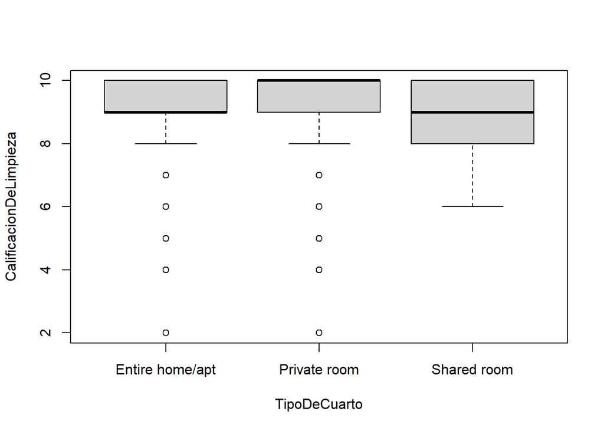

```r
boxplot(CalificacionDeLimpieza~TipoDeCuarto)
```

*Ejecutamos el codigo de anova:*

```r
anova<-aov(lm(CalificacionDeLimpieza~TipoDeCuarto))
summary(anova)
```

```
##                Df Sum Sq Mean Sq F value   Pr(>F)
## TipoDeCuarto    2   29.1  14.548   15.04 3.15e-07 ***
## Residuals    3127 3024.0   0.967
## ---
## Signif. codes:  0 '***' 0.001 '**' 0.01 '*' 0.05 '.' 0.1 ' ' 1
```

Con esto podemos ver que el valor p es mas pequeño que 0.05 por lo que podemos rechazar la hipotesis nula y decir que existen medias diferentes entre los grupos. Por lo que en este caso resulta pertinente realizar un Pos-anova para mirar cual es la relacion entre sus medias:

*Ejecutamos el codigo del Pos-anova*

```r
TukeyHSD(anova)
```

```
##   Tukey multiple comparisons of means
##     95% family-wise confidence level
##
## Fit: aov(formula = lm(CalificacionDeLimpieza ~ TipoDeCuarto))
##
## $TipoDeCuarto
##                                    diff        lwr         upr     p adj
## Private room-Entire home/apt  0.2060760  0.1096319  0.30252005 0.0000017
## Shared room-Entire home/apt  -0.2720018 -0.6117302  0.06772652 0.1454159
## Shared room-Private room     -0.4780778 -0.8246943 -0.13146128 0.0035298
```

Teniendo en cuenta el criterio del pos-anova podemos decir que el tipo de alojamiento que:

- El tipo de alojamiento que tiene un cuarto privado tiene en promedio un mayor puntaje que cuando el alojamiento es de una casa o apartamento completo.
- No hay diferencia del puntaje de limpieza entre cuando tienen un cuarto compartido y cuando el alojamiento es de una casa o apartamento completo.
- El tipo de alojamiento que tiene un cuarto compartido tiene en promedio una calificacion de limpieza menor que cuando es un cuarto privado

$$$$

### **Ji-Cuadrado**

Esta sección del informe se va a aplicar los tests de chi cuadrado, en la que se evaluará si existe una relación significativa entre dos variables categóricas. Estos tests se van a aplicar tanto a las variables cuantitativas como a las cualitativas de nuestro estudio:

#### **Fines de negocio vs Posee mas de un cuarto**

$$Ho:
No~existe~relacion~entre~si~es~por~fin~de~negocio~y~si~posee~mas~de~un~cuarto.$$

$$H1:
Existe~relacion~entre~si~es~para~fin~de~negocio~y~si~posee~mas~de~un~cuarto.$$

```r
with(datos,chisq.test(FinesDeNegocios, PoseeMasDeUnCuarto, correct = TRUE))
```

```
##
##  Pearson's Chi-squared test with Yates' continuity correction
##
## data:  FinesDeNegocios and PoseeMasDeUnCuarto
## X-squared = 314.33, df = 1, p-value < 2.2e-16
```

El valor p es muy pequeño por lo que se concluye que si hay una relacion

```r
tabla <- crosstab(FinesDeNegocios,PoseeMasDeUnCuarto,prop.c = TRUE,plot = FALSE)
tabla
```

```
##    Cell Contents
## |-------------------------|
## |                   Count |
## |          Column Percent |
## |-------------------------|
##
## =========================================
##                    PoseeMasDeUnCuarto
## FinesDeNegocios        0        1   Total
## -----------------------------------------
## 0                  1618      704    2322
##                    66.7%   100.0%
## -----------------------------------------
## 1                   808        0     808
##                    33.3%     0.0%
## -----------------------------------------
## Total              2426      704    3130
##                    77.5%    22.5%
## =========================================
```

#### **Tipo de cuarto vs Fines de negocio**

$$Ho:
No~existe~relacion~entre~el~tipo~de~cuarto~y~si~es~para~fines~de~negocios.$$
$$H1:
Existe~relacion~entre~el~tipo~de~cuarto~y~si~es~para~fines~de~negocios.$$

```r
with(datos,chisq.test(TipoDeCuarto, FinesDeNegocios,correct = TRUE))
```

```
##
##  Pearson's Chi-squared test
##
## data:  TipoDeCuarto and FinesDeNegocios
## X-squared = 56.237, df = 2, p-value = 6.143e-13
```

como podemos ver, el valor p es bastante pequeño por lo que nos permite concluir que si existe una relacion entre estos.

```r
tabla <- crosstab(TipoDeCuarto,FinesDeNegocios,prop.c = TRUE,plot = FALSE)
tabla
```

```
##    Cell Contents
## |-------------------------|
## |                   Count |
## |          Column Percent |
## |-------------------------|
##
## ========================================
##                    FinesDeNegocios
## TipoDeCuarto           0       1   Total
## ----------------------------------------
## Entire home/apt    1781     544    2325
##                    76.7%   67.3%
## ----------------------------------------
## Private room        525     233     758
##                    22.6%   28.8%
## ----------------------------------------
## Shared room          16      31      47
##                     0.7%    3.8%
## ----------------------------------------
## Total              2322     808    3130
##                    74.2%   25.8%
## ========================================
```

#### **Cuarto privado vs Posee mas de un cuarto**

$$Ho:
No~existe~relacion~entre~si~el~cuarto~es~privado~y~si~posee~mas~de~un~cuarto.$$

$$H1:
Existe~relacion~entre~si~es~para~cuarto~privado~y~si~posee~mas~de~un~cuarto.$$

```r
with(datos,chisq.test(CuartoPrivado,PoseeMasDeUnCuarto,correct = TRUE))
```

```
##
##  Pearson's Chi-squared test with Yates' continuity correction
##
## data:  CuartoPrivado and PoseeMasDeUnCuarto
## X-squared = 141.43, df = 1, p-value < 2.2e-16
```

Aqui podemos ver el valor p el cual vuelve a ser muy pequeño (menor a 0.05), entonces podemos concluir que si existe una relacion entre cuarto privado y si posee mas de un cuarto.

```r
tabla <- crosstab(CuartoPrivado,PoseeMasDeUnCuarto,prop.c = TRUE,plot = FALSE)
tabla
```

```
##    Cell Contents
## |-------------------------|
## |                   Count |
## |          Column Percent |
## |-------------------------|
##
## ======================================
##                  PoseeMasDeUnCuarto
## CuartoPrivado        0       1   Total
## --------------------------------------
## FALSE            1958     414    2372
##                  80.7%   58.8%
## --------------------------------------
## TRUE              468     290     758
##                  19.3%   41.2%
## --------------------------------------
## Total            2426     704    3130
##                  77.5%   22.5%
## ======================================
```

### **Regresion lineal - Distancia al centro vs Precio final**

Dentro de esta seccion del informe se va a plantear una regresion lineal entre las varaibles de distancia al centro de la ciudad, siendo esta la variable independiente y el precio final del alojamiento que seria la variable dependiente. Sin embargo cuando graficamos estas 2 variables en una grafico de dispersion tenemos el siguiente resultado:

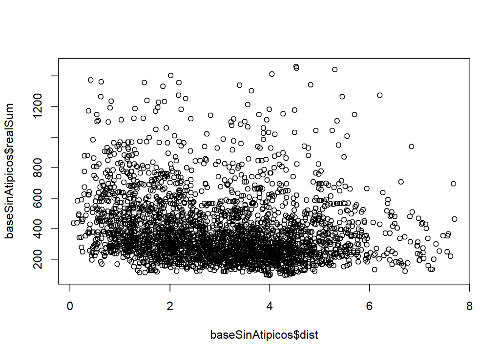

```r
#names(Paris_weekdays)
baseSinAtipicos <- filter(Paris_weekdays, Paris_weekdays$realSum < 1500)

plot(baseSinAtipicos$dist, baseSinAtipicos$realSum)
```

Aqui podemos ver que los datos estan muy dispersos y no siguen alguna tendencia que se pueda observar a simple vista. Esto se debe a que realmente el precio de un alojamiento en AirBnb no depende exclusivamente de la distancia al centro de la ciudad, sino tambien por otros atributos como si es compartido o privado, los metros cuadrados que tiene o sus acabados. Es por esto que para este caso vamos a fijar una de las variables que intervienen en nuestro modelo que seria el del tipo de alojamiento y lo vamos a fijar como “Cuarto compartido”. A continuacion se ve el grafico de dispersion de esto:

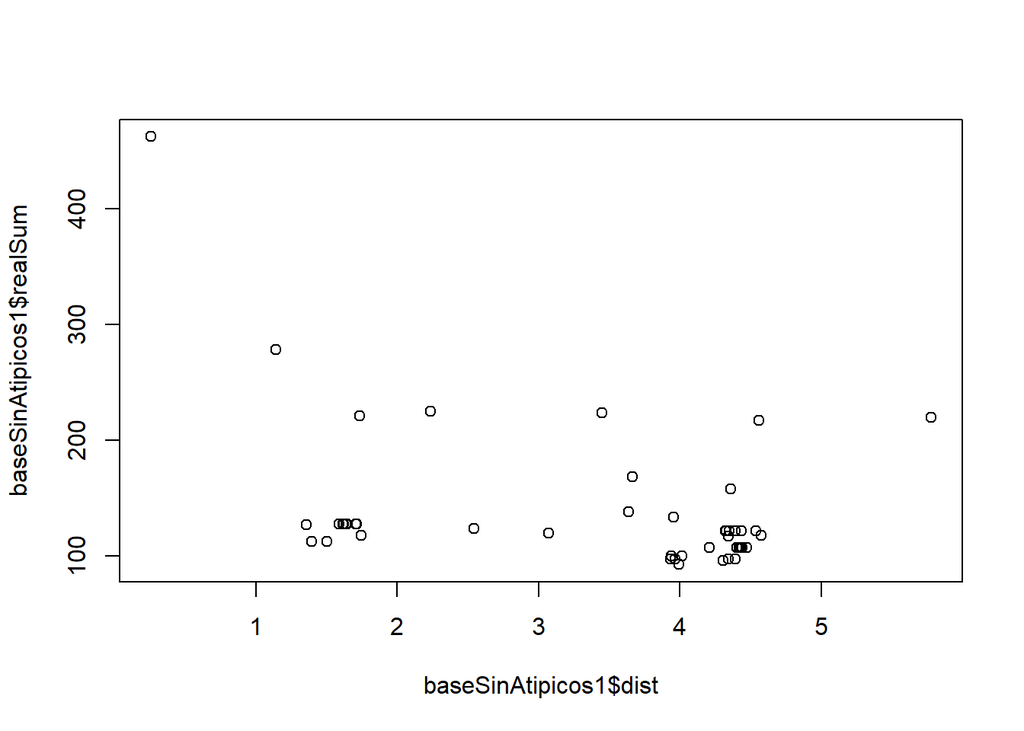

```r
baseSinAtipicos1 <-  filter(baseSinAtipicos, baseSinAtipicos$room_type == "Shared room")

plot(baseSinAtipicos1$dist, baseSinAtipicos1$realSum)
```

#### **Formulacion de hipotesis:**

##### **Relacion entre las variables**

Queremos probar si hay una relacion entre la distancia del alojamiento y el precio , por lo que se hacen la siguientes hipotesis:

$$H_0: \rho = 0$$
$$H_1: \rho \neq 0$$

```r
cor.test(baseSinAtipicos1$dist, baseSinAtipicos1$realSum)
```

```
##
##  Pearson's product-moment correlation
##
## data:  baseSinAtipicos1$dist and baseSinAtipicos1$realSum
## t = -2.8146, df = 45, p-value = 0.00722
## alternative hypothesis: true correlation is not equal to 0
## 95 percent confidence interval:
##  -0.6066608 -0.1121948
## sample estimates:
##        cor
## -0.3868964
```

##### **Prueba de linealidad**

A continuacion hacemos la prueba de linealidad en nuestro modelo:

$$H_0: \beta_1 = 0$$
$$H_1: \beta_1 \neq 0$$

```r
Regresion <- lm(baseSinAtipicos1$realSum~dist, data = baseSinAtipicos1)
summary(Regresion)
```

```
##
## Call:
## lm(formula = baseSinAtipicos1$realSum ~ dist, data = baseSinAtipicos1)
##
## Residuals:
##     Min      1Q  Median      3Q     Max
## -62.818 -33.179 -12.462   3.187 266.424
##
## Coefficients:
##             Estimate Std. Error t value Pr(>|t|)
## (Intercept)  200.521     23.237   8.630 4.26e-11 ***
## dist         -18.204      6.468  -2.815  0.00722 **
## ---
## Signif. codes:  0 '***' 0.001 '**' 0.01 '*' 0.05 '.' 0.1 ' ' 1
##
## Residual standard error: 59.16 on 45 degrees of freedom
## Multiple R-squared:  0.1497, Adjusted R-squared:  0.1308
## F-statistic: 7.922 on 1 and 45 DF,  p-value: 0.00722
```

Vemos que nuestro valor p es bastante menor que nuestro nivel de significancia ya que $0.00722 < 0.05$, por lo que se rechaza $H_0$ y podemos decir que si existe una relacion lineal entre las variables.

El modelo de regresion que se ajusta a este caso es el siguiente:

$$\hat{Y} = \beta_0 + \beta_1X$$
$$\hat{Y} = 200.5 -18.2X$$

#### **Supuestos de la regresion (Residuos)**

Con el siguiente codigo sacamos todos los residuos de nuestro modelo de regresion:

```r
Residuos <- residuals(Regresion)
```

##### **Supuesto de normalidad**

$$H_0:
Los~residuos~se~distribuyen~de~forma~normal$$
$$H_1:
Los~residuos~no~se~distribuyen~de~forma~normal$$

$$$$

```r
shapiro.test(Residuos)
```

```
##
##  Shapiro-Wilk normality test
##
## data:  Residuos
## W = 0.74989, p-value = 1.416e-07
```

Según el resultado del test de Shapiro, el valor p obtenido es menor que el nivel de significancia establecido (alfa), lo que indica que debemos rechazar la hipótesis nula ($H_0$). En consecuencia, podemos concluir que los residuos no siguen una distribución normal.

No obstante, podemos considerar la asunción de normalidad en los residuos debido al **Teorema Central del Límite**, ya que se ha utilizado un tamaño de muestra mayor a 30.

##### **Supuesto de homogeneidad**

Para esta prueba vamos a usar el test de Breush Pagan y vamos a plantear las siguientes hipotesis:

$$H_0:
Los~residuos~presentan~varianzas~constante.$$
$$H_1:
Los~residuos~no~presentan~varianzas~constante.$$

```r
bptest(Regresion)
```

```
##
##  studentized Breusch-Pagan test
##
## data:  Regresion
## BP = 0.59584, df = 1, p-value = 0.4402
```

Vemos que el valor p ($0.44$) es mayor que nuestro alfa, por lo que no podemos rechazar la hipotesis nula y por lo tanto podemos decir que los residuos si tienen varianzas constantes.

#### **Supuesto de independencia**

En este caso no podemos aplicar la prueba de independencia de los residuos puesto que el analisis entre la distancia y el precio final no tiene series de tiempo.

#### **Intervalos de confianza**

A continuacion se muestran los intervalos de confianza del modelo de regresion con un intervalo entre 0 km y 6km con saltos de 0.1 km:

```r
rango <- seq(0, 6, by = 0.1)
nuevos_valores <- data.frame(dist = rango)
intervalos_confianza <- predict(Regresion, newdata = nuevos_valores, interval = "confidence", level = 0.95)
intervalos_confianza
```

[output not shown]

[output cut: 47 more lines]

#### **Intervalos de prediccion**

A continuacion se muestran los intervalos de prediccion del modelo de regresion con un intervalo entre 0 km y 6km con saltos de 0.1 km:

```r
predicciones <- predict(Regresion, newdata = nuevos_valores, interval = "prediction", level = 0.95)
predicciones
```

[output not shown]

[output cut: 47 more lines]